# Praca domowa 2

Emilia Olszewska

## Dane

Dane wykorzystane w Pracy domowej 2 dotyczą wyników egzaminów z 3 umiejętności: czytania, pisania i operacji matematycznych. Dodatkowo dostępne są podstawowe informacje o studentach i ich rodzicach. Opis wszystkich kolumn znajduje się również w pliku `README.md`.

| Zmienna | Opis |
| --- | --- |
| **gender** | płeć |
| **race.ethnicity** | pochodzenie etniczne |
| **parental.level.of.education** | wykształcenie rodziców |
| **lunch** | jaki obiad jedli uczniowie w dniu egzaminu |
| **test.preparation.course** | czy uczeń odbył kurs przygotowujący |
| **math.score** | wynik egzaminu z matematyki |
| **reading.score** | wynik egzaminu z czytania |
| **writing.score** | wynik egzaminu z pisania |

## Zadanie 1

Jak wyglądają rozkłady wyników uczniów z trzech przedmiotów (matematyka, czytanie, pisanie)?

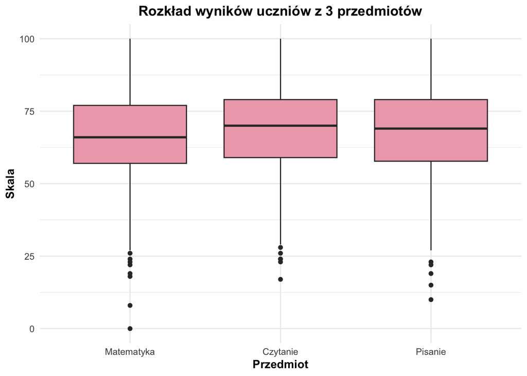

```r
df_1 <- df%>%
  pivot_longer(cols = c(math.score, reading.score, writing.score),names_to = "subject", values_to = "score")
View(df_1)

df_1%>%
  ggplot(aes(x= subject,y=score))+
  geom_boxplot(fill= 'pink2')+
  labs(title= "Rozkład wyników uczniów z 3 przedmiotów",x = "Przedmiot", y= "Skala")+
  scale_x_discrete(labels = c("math.score" = "Matematyka", "reading.score" = "Czytanie","writing.score" ="Pisanie"))+
  theme_minimal()+
  theme(legend.title = element_text( face = 'bold'),
        axis.title = element_text(face = 'bold'),
        plot.title = element_text(face='bold',hjust = 0.5))
```

**Komentarz:** Rozkłady wyników uczniów są bardzo zbliżone. Widoczne jest jednak, że uczniowie gorzej radzą sobie z matematyką. Egzmain ten ma najniższą medianę, oraz pojawiają się pojedyncze wartości bliskie 0 - co nie występuje odczas egzaminu z czytania i pisania. Niewielka przewaga czytania nad pisaniem decyduje, że z egzmainu z czytania uczniowie otrzymują najwyższe wyniki ( róźnica jest jednak mininlana).

## Zadanie 2

Czy istnieje zauważalna różnica w wynikach między uczniami i uczennicami?

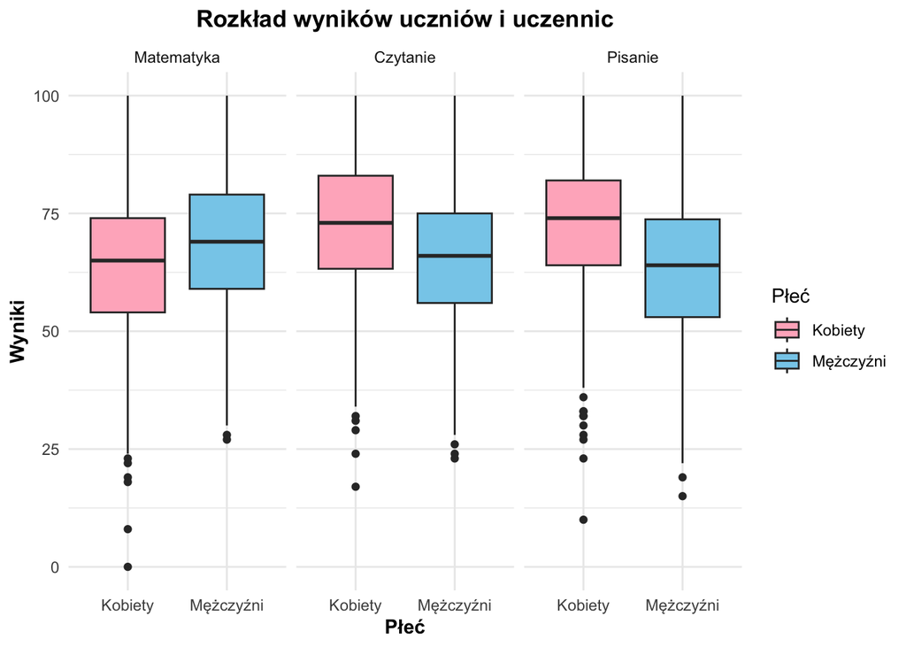

```r
df_1%>%
  ggplot(aes(x = gender, y = score,fill = gender))+
  geom_boxplot()+
  facet_wrap(~subject,nrow=1,labeller = as_labeller(c(
    "math.score" = "Matematyka",
    "reading.score" = "Czytanie",
    "writing.score" = "Pisanie")))+
  scale_fill_manual(values = c("pink1", "skyblue"), labels = c("Kobiety","Mężczyźni"))+
  labs(title= "Rozkład wyników uczniów i uczennic",x = "Płeć", y= "Wyniki",fill="Płeć")+
  scale_x_discrete(labels = c("female" = "Kobiety", "male" = "Mężczyźni"))+
  theme_minimal()+
  theme( axis.title = element_text(face = 'bold'),
        plot.title = element_text(face='bold',hjust = 0.5))
```

**Komentarz:** Tak istnieje zauważalna różnica w wynikach między uczennicami i uczniami. Mężczyźni radzą sobie lepiej z matematyką. Kobiety natomiast dużo lepiej zdają egzaminy z czytania i pisania( większa mediana). Jednak podczas wszytskich egzmainów widać, że u kobiet występuje większa ilość punktów odstających, co może świadczyć o większym zróżnicowaniu wyników.

## Zadanie 3

Czy uczniowie, którzy ukończyli kurs przygotowawczy, osiągają lepsze wyniki niż pozostali?

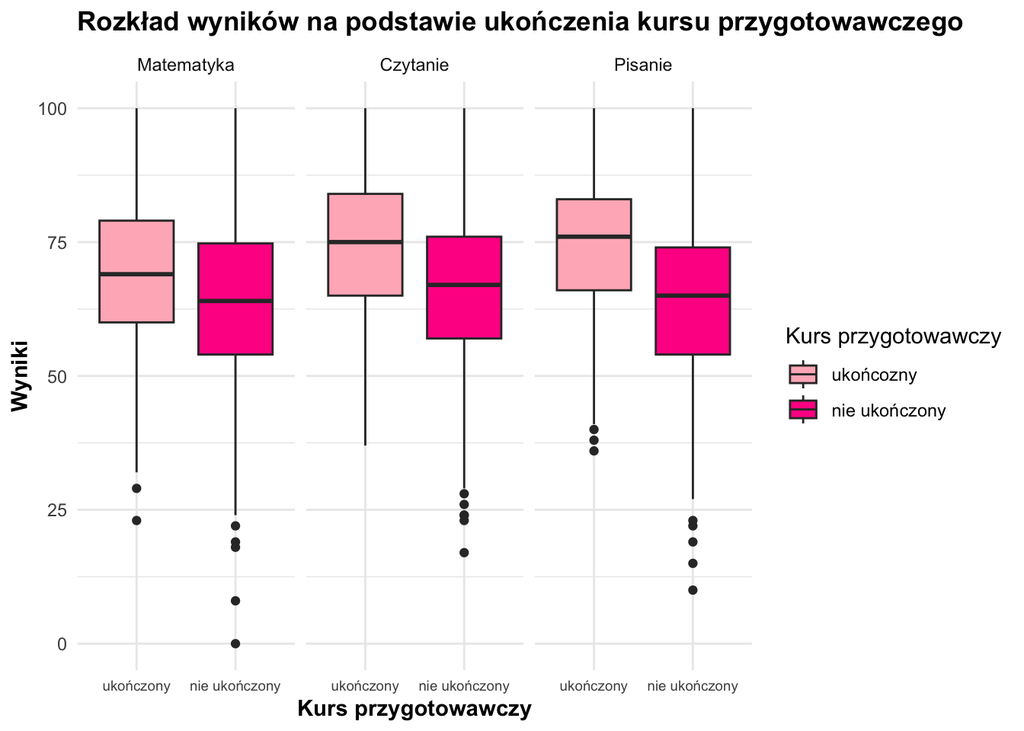

```r
df_1%>%
  ggplot(aes(x = test.preparation.course, y = score, fill = test.preparation.course))+
  geom_boxplot()+
  facet_wrap(~subject,nrow=1,labeller = as_labeller(c(
    "math.score" = "Matematyka",
    "reading.score" = "Czytanie",
    "writing.score" = "Pisanie")))+
  scale_fill_manual(values = c('lightpink','deeppink'),labels =c("ukońcozny","nie ukończony"))+
  labs(title= "Rozkład wyników na podstawie ukończenia kursu przygotowawczego",x = "Kurs przygotowawczy", y= "Wyniki",fill = 'Kurs przygotowawczy')+
  scale_x_discrete(labels = c("completed" = "ukończony", "none" = "nie ukończony"))+
  theme_minimal()+
  theme( axis.title = element_text(face = 'bold'),
       plot.title = element_text(face='bold'),
       axis.text.x = element_text(size=7))
```

**Komentarz:** Na podstawie wykresu, można stwierdzić, że uczniowie którzy ukończyli kurs osiągają wyższe wyniki ze wszystkich 3 przedmiotów. Widoczny jest także minimalny poziom wartości odstjących w porównaniu do grupy uczniów, która nie brała udziału w kursie.

## Zadanie 4

Jaki jest związek między poziomem wykształcenia rodziców a średnimi wynikami uczniów?

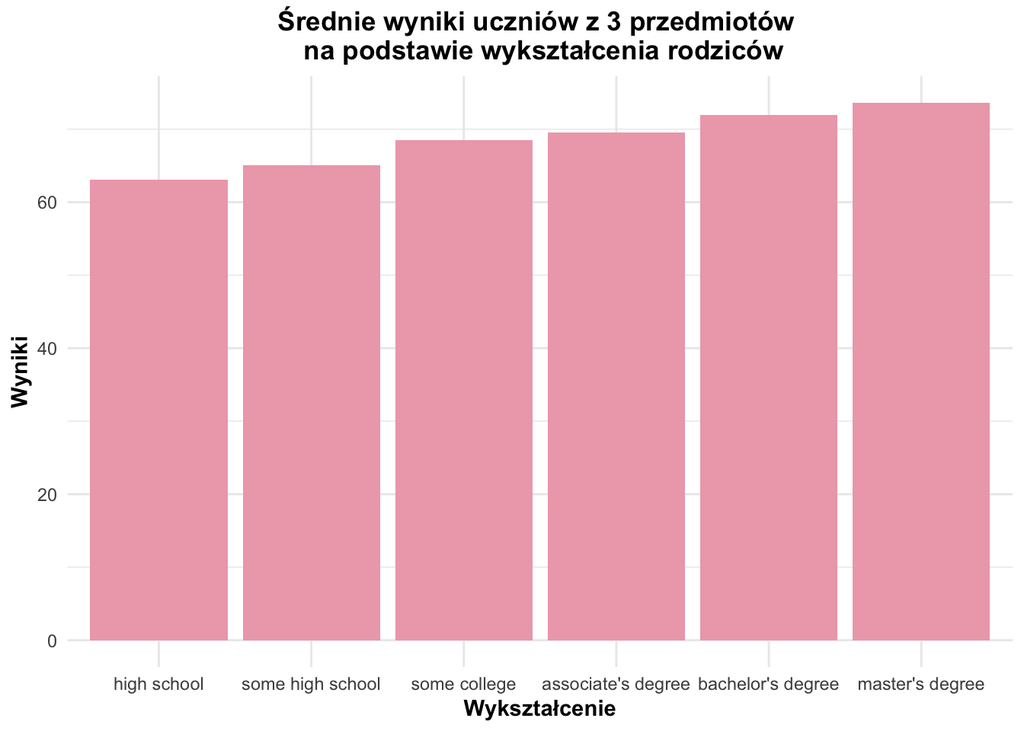

```r
df_4<-df_1%>%
  group_by(parental.level.of.education) %>%
  summarise(mean_score = mean(score, na.rm = TRUE), .groups="drop")

df_4%>%
  ggplot(aes(x =reorder(parental.level.of.education,mean_score), y = mean_score))+
  geom_col(fill = 'pink2')+
  labs(title= "Średnie wyniki uczniów z 3 przedmiotów \n na podstawie wykształcenia rodziców",x = "Wykształcenie", y= "Wyniki")+
  theme_minimal()+
  theme( axis.title = element_text(face = 'bold'),
       plot.title = element_text(face='bold',hjust = 0.5))
```

**Komentarz:** Na podstawie wykresu, można stwierdzić, że wykształcenie rodziców ma wpływ na wyniki uczniów. Najlepiej radzą sobie dzieci, których rodzice mają wykształcenie wyższe ( tytuł licencjata lub magistra). Wraz ze słabszymi wynikami widzimy spadek poziomu wykształcenia rodziców. Jednak zaskoczeniem jest fakt, że najgorzej radzą sobie dzieci rodziców z wykształceniem średnim (oczekiwana grupa: nieskończone liceum)

## Zadanie 5

Czy płeć i wykształcenie rodzica wpływa na wynik z matematyki?

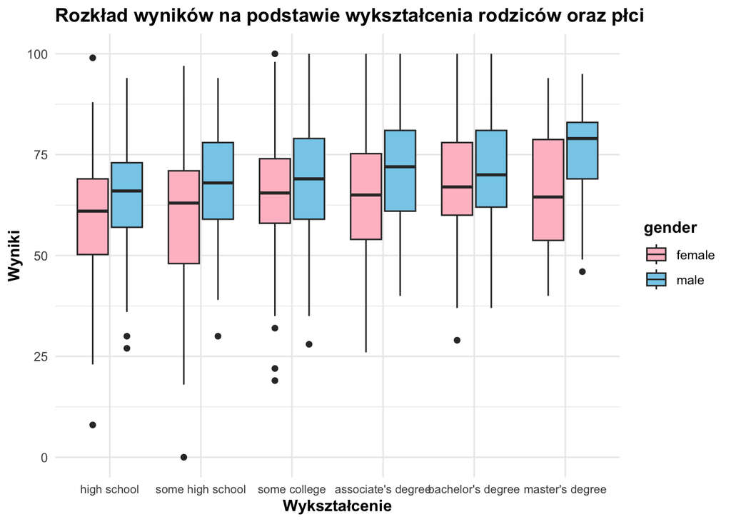

```r
df%>%
  ggplot(aes(x =reorder(parental.level.of.education,math.score), y = math.score,fill = gender))+
  geom_boxplot()+
  labs(title= "Rozkład wyników na podstawie wykształcenia rodziców oraz płci",x = "Wykształcenie", y= "Wyniki")+
  scale_fill_manual(values = c('pink','skyblue'))+
  theme_minimal()+
  theme(axis.title = element_text(face = 'bold'),
       plot.title = element_text(face='bold'),
       legend.title = element_text(face = 'bold'),
       axis.text.x = element_text(size=8))
```

## Zadanie 6

Czy istnieje zależność między wynikami z matematyki a wynikami z czytania lub pisania?

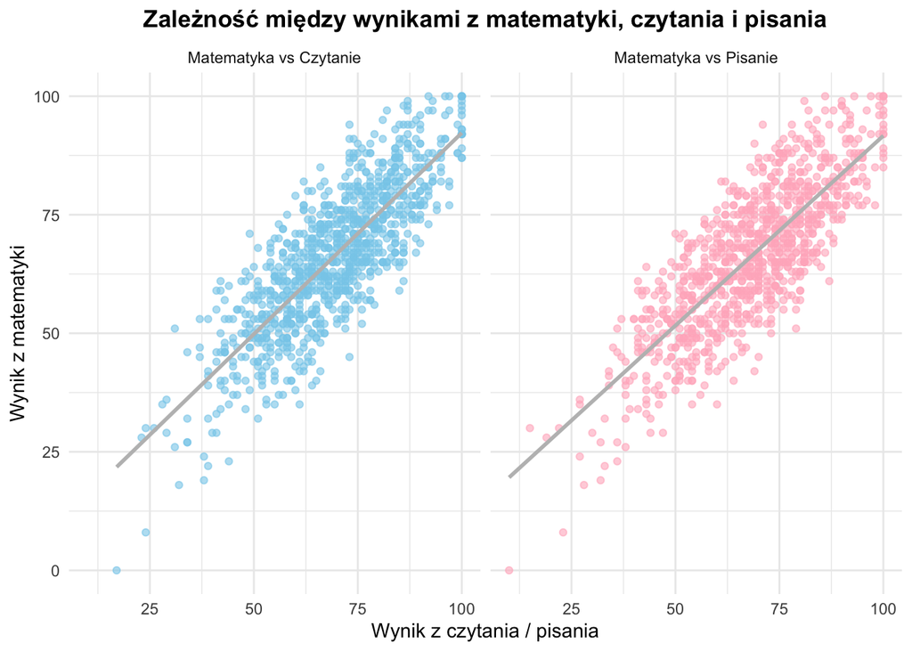

```r
df_6 <-  df %>%
  pivot_longer(
    cols = c(reading.score, writing.score),
    names_to = "subject",
    values_to = "score"
  )

df_6%>%
ggplot( aes(x = score, y = math.score, color = subject)) +
  geom_point(alpha = 0.6) +
  geom_smooth(method = "lm", se = FALSE,color="grey", linewidth = 1) +
  facet_wrap(~subject, nrow = 1, labeller = as_labeller(c(
    "reading.score" = "Matematyka vs Czytanie",
    "writing.score" = "Matematyka vs Pisanie"
  ))) +
  scale_color_manual(values = c("reading.score" = "skyblue", "writing.score" = "pink1")) +
  labs(
    title = "Zależność między wynikami z matematyki, czytania i pisania",
    x = "Wynik z czytania / pisania",
    y = "Wynik z matematyki",
    color = "Przedmiot"
  ) +
  theme_minimal() +
  theme(
    plot.title = element_text(face = "bold", hjust = 0.5),
    legend.position = "none"
  )
```

**Komentarz:** Na podstawie wykresu można stwierdzić, że istnieje silna zależność między wynikami uczniów z matematyki a wynikami z czytania i pisania.Na obu wykresach punkty rozłożone są wzdłóż linii trendu - oznacza to, że uczniowie którzy uzyskują wysokie wyniki z czytania i pisania otrzymują także wysokie wyniki z matematyki.